# homework6

Yihan Feng

12/4/2020

### Problem 1

Create a plot that shows the estimated ORs and CIs for each city. Organize cities according to estimated OR, and comment on the plot.

```r
homicide_df =
  read_csv("data/homicide-data.csv", na = c("", "NA", "Unknown")) %>%
  mutate(
    city_state = str_c(city, state, sep = ", "),
    victim_age = as.numeric(victim_age),
    resolution = case_when(
      disposition == "Closed without arrest" ~ 0,
      disposition == "Open/No arrest"        ~ 0,
      disposition == "Closed by arrest"      ~ 1)
  ) %>%
  filter(
    victim_race %in% c("White", "Black"),
    city_state != "Tulsa, AL") %>%
  select(city_state, resolution, victim_age, victim_race, victim_sex)
```

Start with one city.

```r
baltimore_df =
  homicide_df %>%
  filter(city_state == "Baltimore, MD")
glm(resolution ~ victim_age + victim_race + victim_sex,
    data = baltimore_df,
    family = binomial()) %>%
  broom::tidy() %>%
  mutate(
    OR = exp(estimate),
    CI_lower = exp(estimate - 1.96 * std.error),
    CI_upper = exp(estimate + 1.96 * std.error)
  ) %>%
  select(term, OR, starts_with("CI")) %>%
  knitr::kable(digits = 3)
```

| term | OR | CI_lower | CI_upper |
| --- | --- | --- | --- |
| (Intercept) | 1.363 | 0.975 | 1.907 |
| victim_age | 0.993 | 0.987 | 1.000 |
| victim_raceWhite | 2.320 | 1.648 | 3.268 |
| victim_sexMale | 0.426 | 0.325 | 0.558 |

Try this across cities.

```r
models_results_df =
  homicide_df %>%
  nest(data = -city_state) %>%
  mutate(
    models =
      map(.x = data, ~glm(resolution ~ victim_age + victim_race + victim_sex, data = .x, family = binomial())),
    results = map(models, broom::tidy)
  ) %>%
  select(city_state, results) %>%
  unnest(results) %>%
  mutate(
    OR = exp(estimate),
    CI_lower = exp(estimate - 1.96 * std.error),
    CI_upper = exp(estimate + 1.96 * std.error)
  ) %>%
  select(city_state, term, OR, starts_with("CI"))
```

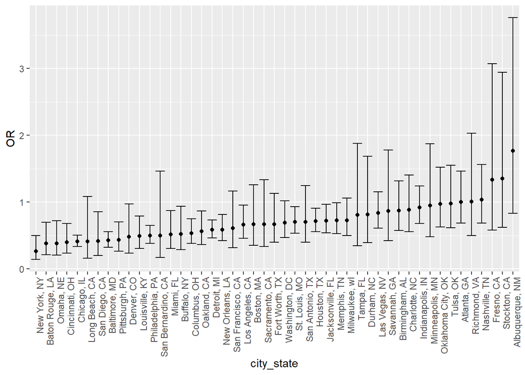

```r
models_results_df %>%
  filter(term == "victim_sexMale") %>%
  mutate(city_state = fct_reorder(city_state, OR)) %>%
  ggplot(aes(x = city_state, y = OR)) +
  geom_point() +
  geom_errorbar(aes(ymin = CI_lower, ymax = CI_upper)) +
  theme(axis.text.x = element_text(angle = 90, hjust = 1))
```

## Problem 2

#### Import and clean the dataset. Check for missing values.

```r
baby_df <-
  read_csv("./data/birthweight.csv") %>%
  mutate(babysex = factor(case_when(babysex == 1 ~ "Male",
                                    babysex == 2 ~ "Female"),
                          levels = c("Male", "Female")),
         dad_race = factor(case_when(frace == 1 ~ "White",
                                     frace == 2 ~ "Black",
                                     frace == 3 ~ "Asian",
                                     frace == 4 ~ "Puerto Rican",
                                     frace == 8 ~ "Other",
                                     frace == 9 ~ "Unknwon"
                                     )),
         mom_race = factor(case_when(mrace == 1 ~ "White",
                                     mrace == 2 ~ "Black",
                                     mrace == 3 ~ "Asian",
                                     mrace == 4 ~ "Puerto Rican",
                                     mrace == 8 ~ "Other"
                                     )),
         malformation = factor(case_when(malform == 1 ~ "Present",
                                         malform == 0 ~ "Absent"),
                               levels = c("Present", "Absent"))) %>%
  select(-frace, -mrace, -malform)


# check for missing values
na <- baby_df %>%
  summarize_all(funs(sum(is.na(.)))) %>%
  knitr::kable()
```

```r
gaweeks_model <- lm(bwt ~ gaweeks, data = baby_df)
```

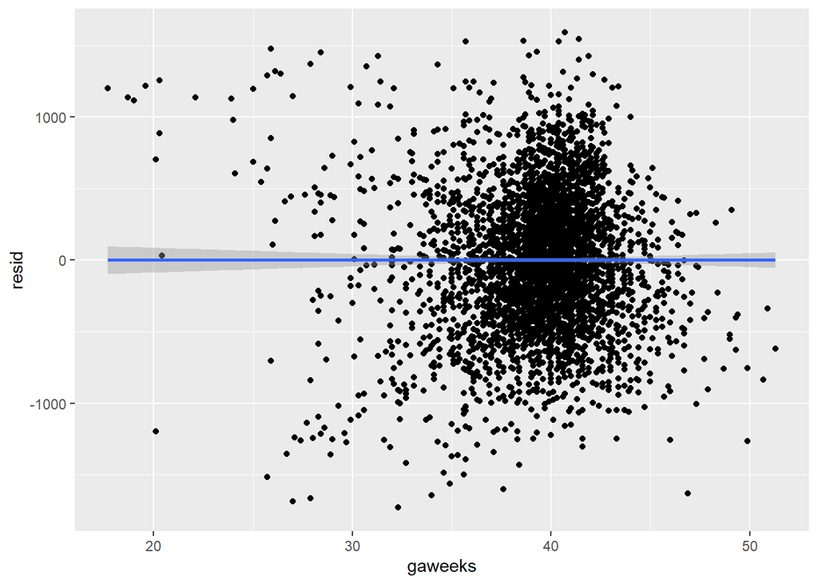

```r
baby_df %>%
  add_residuals(gaweeks_model) %>%
  add_predictions(gaweeks_model) %>%
  ggplot(aes(x = gaweeks, y = resid)) +
  geom_point() +
  geom_smooth(method = "lm")
```

```r
  labs(title = "Residuals vs. Predicted Values for Birthweight Model",
       x = "gestational age (week)",
       y = "Residuals")
```

```
## $x
## [1] "gestational age (week)"
##
## $y
## [1] "Residuals"
##
## $title
## [1] "Residuals vs. Predicted Values for Birthweight Model"
##
## attr(,"class")
## [1] "labels"
```

#### Compare with other two models.

```r
lg_model <- lm(bwt ~ blength + gaweeks, data = baby_df)
hls_model <- lm(bwt ~ bhead * blength * babysex, data = baby_df)
```

2. Cross Validation

```r
crossv_df <-
  crossv_mc(baby_df, 100) %>%
  mutate(
    train = map(train, as_tibble),
    test = map(test, as_tibble)
  ) %>%
  mutate(
    gaweeks_model = map(train, ~lm(bwt ~ gaweeks, data = .x)),
    lg_model = map(train, ~lm(bwt ~ blength + gaweeks, data = .x)),
    hls_model = map(train, ~lm(bwt ~ bhead + blength + babysex, data = .x))
  ) %>%
  mutate(
    gaweeks_model_rmse = map2_dbl(gaweeks_model, test, ~rmse(model = .x, data = .y)),
    lg_model_rmse = map2_dbl(lg_model, test, ~rmse(model = .x, data = .y)),
    hls_model_rmse = map2_dbl(hls_model, test, ~rmse(model = .x, data = .y))
    )
```

3. Visualization

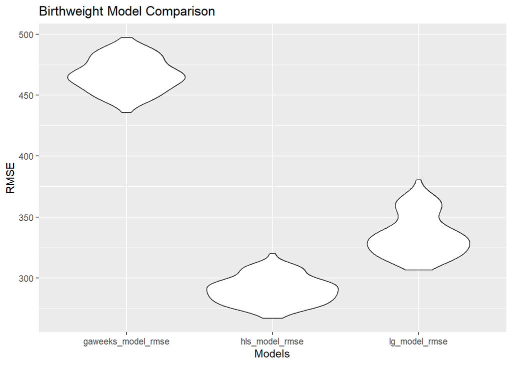

```r
crossv_df %>%
  select(gaweeks_model_rmse, lg_model_rmse, hls_model_rmse) %>%
  pivot_longer(everything(),
             names_to = "model",
             values_to = "rmse") %>%
  ggplot(aes(x = model, y = rmse)) +
  geom_violin() +
  labs(
    title = "Birthweight Model Comparison",
    x = "Models",
    y = "RMSE"
  )
```

## Problem 3

#### Import the raw data and select the interested data

```r
weather_df =
  rnoaa::meteo_pull_monitors(
    c("USW00094728"),
    var = c("PRCP", "TMIN", "TMAX"),
    date_min = "2017-01-01",
    date_max = "2017-12-31") %>%
  mutate(
    name = recode(id, USW00094728 = "CentralPark_NY"),
    tmin = tmin / 10,
    tmax = tmax / 10) %>%
  select(name, id, everything())
```

#### Bootstrap model

```r
bootstrap_df <-
  modelr::bootstrap(weather_df, n = 5000) %>%
  mutate(model = map(strap, ~lm(tmax ~ tmin, data = .x)),
         result = map(model, broom::tidy),
         r_2 = map(model, broom::glance)) %>%
  select(-strap, -model) %>%
  unnest(result, r_2) %>%
  select(.id, term, estimate, r.squared) %>%
  pivot_wider(
    names_from = term,
    values_from = estimate
  )
bootstrap_df <-
  bootstrap_df %>%
  rename(beta_0 = "(Intercept)", beta_1 = "tmin") %>%
  mutate(log = log(beta_1 * beta_0))
```

#### Visualization of the estimates

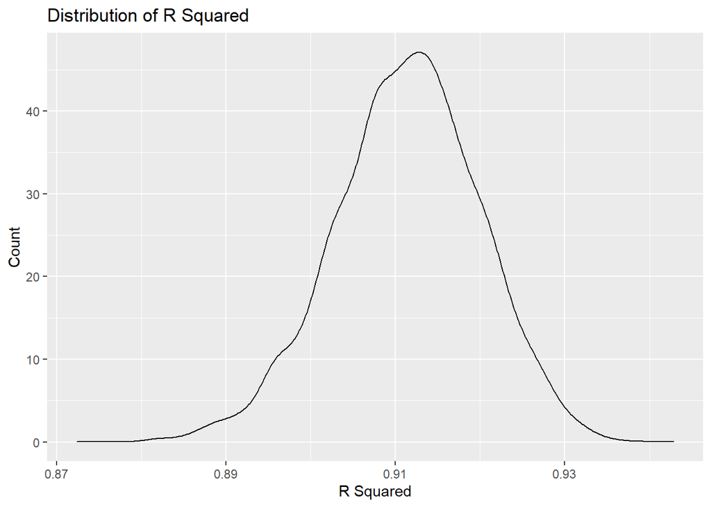

```r
r_2_plot <-
  bootstrap_df %>%
  ggplot(aes(x = r.squared)) +
  geom_density() +
  labs(
    title = "Distribution of R Squared",
    x = "R Squared",
    y = "Count")


log_plot <-
  bootstrap_df %>%
  ggplot(aes(x = log)) +
  geom_density() +
  labs(
    title = "Distribution of Log",
    x = "Log(beta_0 * beta_1)",
    y = "Count"
  )


r_2_plot
```

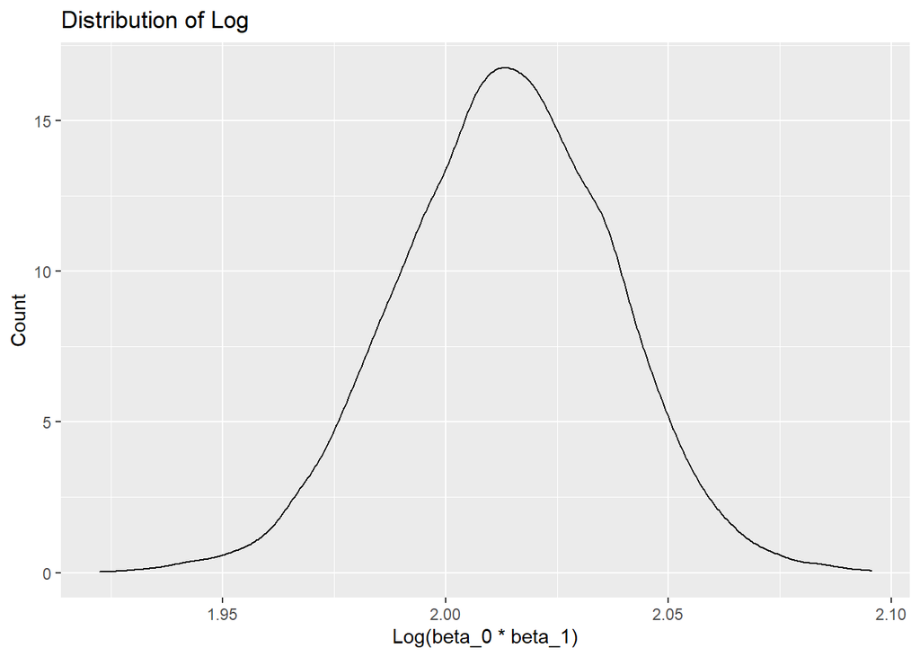

```r
log_plot
```

Comment: Based on the two plots, I found that both $\hat{r}^2$ and $log(\hat{\beta}_0*\hat{\beta}_1)$ have bell shapes and follow normal distribution. The mean value of $\hat{r}^2$ is about 0.91, and the mean value of $log(\hat{\beta}_0*\hat{\beta}_1)$ is about 2.02.

#### 2.5% and 97.5% Quantiles

```r
ci_df <-
  bootstrap_df %>%
  summarize(r2_lower = quantile(r.squared, 0.025),
            r2_upper = quantile(r.squared, 0.975),
            log_lower = quantile(log, 0.025),
            log_upper = quantile(log, 0.975)
            )
```

The 95% confidence interval for $\hat{r}^2$ is (0.8937601, 0.9274236)

The 95% confidence interval for $log(\hat{\beta}_0*\hat{\beta}_1)$ is (1.9662328, 2.058638)